# IODS course project

Ghaida Azzahra

# Introduction to Open Data Science - Course Project

# Assignment 1

```r
date()
```

```
## [1] "Mon Nov 21 23:56:50 2022"
```

> Hello! My name is Ghaida, you can also call me Gege. I am a first year master’s student at University of Helsinki’s Contemporary Societies program.
- I am feeling quite well today. I hope I will be able to use R more comfortably after this course!
- I actually took this course last year from the MOOC, but I did not get to do the peer review part because I did it outside of the planned schedule..
- I first found this course last year when I was hunting for a master’s program. I decided to take the course to get ‘a try’ on a learning experience at the University of Helsinki.
- As I have taken the Quantitative Research Skill course last period, I have already done skimming the R for Health Data Science book, but it was nice to do a quick review. It was a lot of materials for sure! However, I like the active reading approach. My favorite part is creating plots! The most difficult part is probably data wrangling because so many things can go wrong.

> [Click here to visit my Github page!](https://github.com/ghaidana/IODS-project)  
> [Click here to see my Learning Diary!](https://ghaidana.github.io/IODS-project/)

# Assignment 2: Regression and Model Validation

- This week, we are learning about regression and model validation. In this exercise, we are using a data from the International Survey of Approaches to Learning. In this survey, the students were asked to assess themselves on the scale of 1-5 about various statements related to their learning (ex: “I organize my study time carefully to make the best use of it”). The questions could be classified into three different learning approaches: strategic learning, surface learning, and deep learning. Beside the questions about the student’s learning approach, the data also includes questions about the student’s attitude on statistics, age, exam points, and gender.
- We have wrangled the original data to obtain a new dataframe which contains the students’ average assessment score for each learning approaches, average attitude towards statistics, and their personal data.
- In this report, we will use the new dataframe to analyze the relationship between the variables.

```r
date()
```

```
## [1] "Mon Nov 21 23:56:50 2022"
```

## Reading the data

```r
data <- read.csv(file = "learning2014.csv", sep=",", header = TRUE)
```

## Examining the structure and dimension of the data

```r
dim(data)
```

```
## [1] 166   7
```

```r
str(data)
```

```
## 'data.frame':    166 obs. of  7 variables:
##  $ gender  : chr  "F" "M" "F" "M" ...
##  $ Age     : int  53 55 49 53 49 38 50 37 37 42 ...
##  $ attitude: num  3.7 3.1 2.5 3.5 3.7 3.8 3.5 2.9 3.8 2.1 ...
##  $ deep    : num  3.58 2.92 3.5 3.5 3.67 ...
##  $ stra    : num  3.38 2.75 3.62 3.12 3.62 ...
##  $ surf    : num  2.58 3.17 2.25 2.25 2.83 ...
##  $ Points  : int  25 12 24 10 22 21 21 31 24 26 ...
```

The data has 166 observations and 7 variables, which are:

| Variable name | Description |
| --- | --- |
| gender | Gender of the student (character, F/M) |
| Age | Age of the students in years (integer) |
| attitude | The average score of the student’s attitude towards statistics (numeric) |
| deep | The student’s average score on deep learning approach (numeric) |
| stra | The student’s average score on strategic learning approach (numeric) |
| surf | The student’s average score on surface learning approach |
| Points | The student’s exam points (integer) |

## Overview of the data

```r
#accessing the libraries
library(ggplot2)
library(GGally)
```

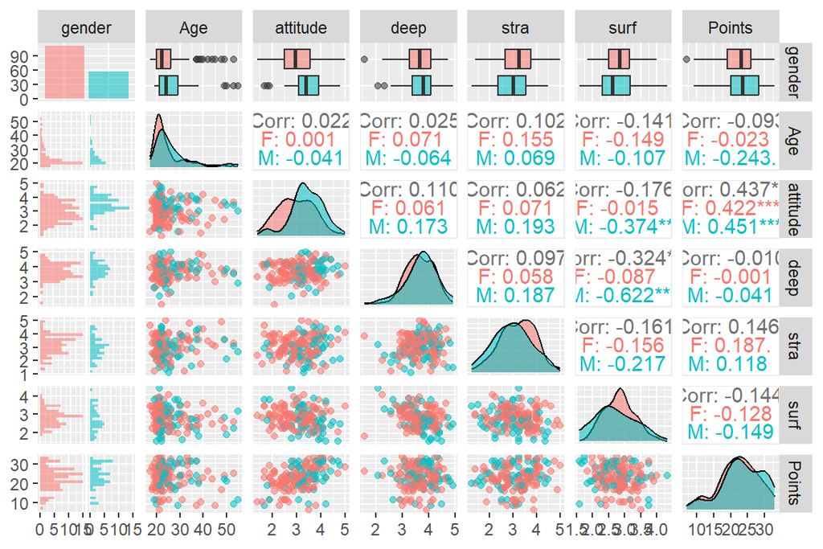

```r
#drawing scatter plot matrix
ggpairs(data, mapping = aes(col=gender, alpha=0.3), lower = list(combo = wrap("facethist", bins = 20)))
```

The data for female students are represented in pink, while the data for male students are represented in green. The frequency graph shows us that we have a lot more data from female students. The students’ age has a highly skewed distribution graph, which tells us that most of the students are on the younger side, but there are a few much older students as well. We can see that the student’s attitude towards statistics are moderately positively correlated with their exam points, which is not surprising. An interesting correlation can be seen between surface and deep learning scores. The two variables have a negative correlation, which means that students who score higher on surface learning tend to score lower in deep learning, and vice versa. However, a moderately high negative correlation is only observed in male students, not in female students. A similar phenomenon can also be observed between surface learning score and the students’ attitude towards statistics.

```r
summary(data)
```

```
##     gender               Age           attitude          deep
##  Length:166         Min.   :17.00   Min.   :1.400   Min.   :1.583
##  Class :character   1st Qu.:21.00   1st Qu.:2.600   1st Qu.:3.333
##  Mode  :character   Median :22.00   Median :3.200   Median :3.667
##                     Mean   :25.51   Mean   :3.143   Mean   :3.680
##                     3rd Qu.:27.00   3rd Qu.:3.700   3rd Qu.:4.083
##                     Max.   :55.00   Max.   :5.000   Max.   :4.917
##       stra            surf           Points
##  Min.   :1.250   Min.   :1.583   Min.   : 7.00
##  1st Qu.:2.625   1st Qu.:2.417   1st Qu.:19.00
##  Median :3.188   Median :2.833   Median :23.00
##  Mean   :3.121   Mean   :2.787   Mean   :22.72
##  3rd Qu.:3.625   3rd Qu.:3.167   3rd Qu.:27.75
##  Max.   :5.000   Max.   :4.333   Max.   :33.00
```

Here, we can see the descriptive statistics of each variable in the data. The students’ age ranges from 17 to 55 years, while the average is 25.5 years old. The students’ attitude towards statistics averages at 3.14, which means that the students have a slightly more positive attitude towards statistics in general. Among the three learning approaches, deep learning has the highest average score while surface learning has the lowest average score. Meanwhile, the students’ exam point ranges from 7 to 33 and averages at 22.7.

## Building the model

```r
library(tidyverse)
```

```r
#3 variables as explanatory variables
fit <- data %>%
  lm(Points ~ attitude + stra + deep , data = .)
summary(fit)
```

```
##
## Call:
## lm(formula = Points ~ attitude + stra + deep, data = .)
##
## Residuals:
##      Min       1Q   Median       3Q      Max
## -17.5239  -3.4276   0.5474   3.8220  11.5112
##
## Coefficients:
##             Estimate Std. Error t value Pr(>|t|)
## (Intercept)  11.3915     3.4077   3.343  0.00103 **
## attitude      3.5254     0.5683   6.203 4.44e-09 ***
## stra          0.9621     0.5367   1.793  0.07489 .
## deep         -0.7492     0.7507  -0.998  0.31974
## ---
## Signif. codes:  0 '***' 0.001 '**' 0.01 '*' 0.05 '.' 0.1 ' ' 1
##
## Residual standard error: 5.289 on 162 degrees of freedom
## Multiple R-squared:  0.2097, Adjusted R-squared:  0.195
## F-statistic: 14.33 on 3 and 162 DF,  p-value: 2.521e-08
```

The low p-value and positive estimate suggest that the student’s attitude towards statistics is significantly and positively related to their exam points. We also found an evidence of a positive relationship between the students’ strategic learning score and their exam points (p-value = 0.075, significant at the 0.1 level). However, we did not find any evidence of a relationship between the students’ deep learning score and their exam points. Next, we will remove this variable and fit the model again without it.

```r
#remove insignificant variable
fit2 <- data %>%
  lm(Points ~ attitude + stra, data = .)
summary(fit2)
```

```
##
## Call:
## lm(formula = Points ~ attitude + stra, data = .)
##
## Residuals:
##      Min       1Q   Median       3Q      Max
## -17.6436  -3.3113   0.5575   3.7928  10.9295
##
## Coefficients:
##             Estimate Std. Error t value Pr(>|t|)
## (Intercept)   8.9729     2.3959   3.745  0.00025 ***
## attitude      3.4658     0.5652   6.132 6.31e-09 ***
## stra          0.9137     0.5345   1.709  0.08927 .
## ---
## Signif. codes:  0 '***' 0.001 '**' 0.01 '*' 0.05 '.' 0.1 ' ' 1
##
## Residual standard error: 5.289 on 163 degrees of freedom
## Multiple R-squared:  0.2048, Adjusted R-squared:  0.1951
## F-statistic: 20.99 on 2 and 163 DF,  p-value: 7.734e-09
```

We obtained a similar result with the previous model. With a very low p-value, the students’ attitude towards statistics was still found to be a highly significant predictor of their exam point. The students’ exam score increases by 3.46 points on average with each increase in the students’ attitude score, assuming that their strategic learning score remains constant. Meanwhile, the students’ strategic learning score was found to be significant at 0.1 level (p-value = 0.08). The student’s exam score increases by 0.91 points on average with each increase in the students’ strategic learning score, assuming that their attitude score remains constant. In another word, students who have a more positive attitude towards statistics and/or practices strategic learning approach tend to have a higher exam point.

The adjusted R-squared of this model was 0.1951, which means that this model explains about 19.51 percent of the variations in the student’s exam point. Considering that this is a very simple model, this is already a quite high R-squared value.

## Diagnostics

In linear regression, we assume a linear correlation between the variables, and the error term/residual is normally distributed. We also assume that the variance of the residuals are equal across all predicted values (homoscedasticity). The residuals vs. fitted values plot and the Q-Q plot can be used to check these assumptions.

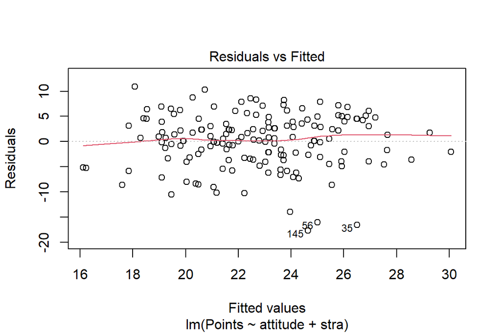

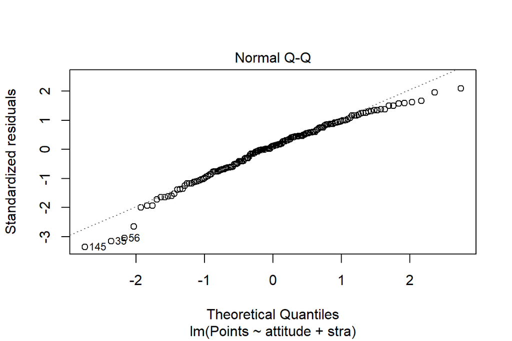

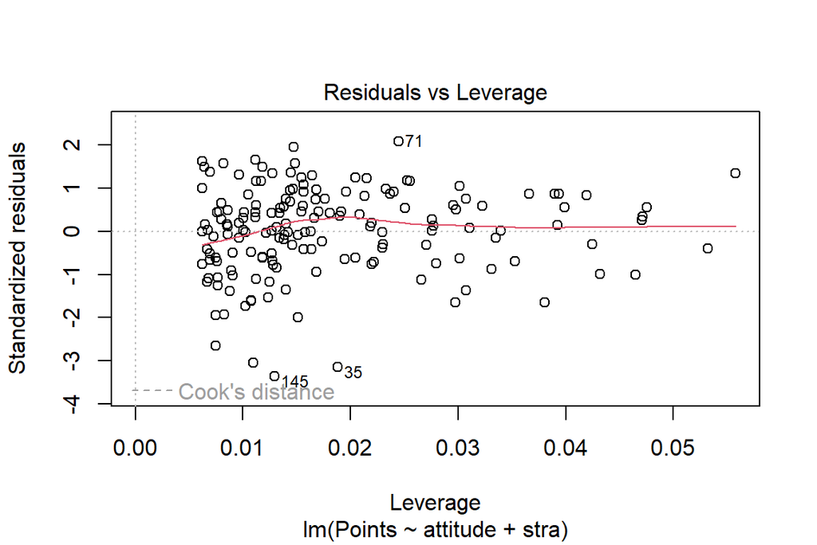

```r
plot(fit2, which = c(1, 2, 5))
```

In the residuals vs. fitted values plot, we can see that the residuals seem to be randomly scattered. It does not seem to display any concerning patterns, such as a curve (suggesting non-linearity) or a trombone pattern (suggesting heteroscedasticity). Based on this plot, it seems that the data is linear and homoscedastic (the variance of the residuals tend to be equal across all predicted values).

The Q-Q plot compares the standardized residuals to their theoretical quantiles (the values they should have if the normality assumption is fulfilled). If the assumption is fulfilled, the points should fall across the straight line. In this plot, we can see that the points seem to form a slight upward curve. This means that the distribution of the residuals are actually a bit left skewed.

The residuals vs leverage plot is used to check if there is any outliers that might affect the model heavily. There seem to be several extreme values in the data, but none of them fall outside of the Cook’s distance line, so they are not necessarily considered to be influential to the model.

# Assignment 3: Logistic Regression

```r
date()
```

```
## [1] "Mon Nov 21 23:57:02 2022"
```

## Setting up

### Reading the data

```r
data <- read.csv(file = "alc.csv", sep=",", header = TRUE)
```

### Explaining the data

```r
#printing out the variables name
colnames(data)
```

```
##  [1] "school"     "sex"        "age"        "address"    "famsize"
##  [6] "Pstatus"    "Medu"       "Fedu"       "Mjob"       "Fjob"
## [11] "reason"     "guardian"   "traveltime" "studytime"  "schoolsup"
## [16] "famsup"     "activities" "nursery"    "higher"     "internet"
## [21] "romantic"   "famrel"     "freetime"   "goout"      "Dalc"
## [26] "Walc"       "health"     "failures"   "paid"       "absences"
## [31] "G1"         "G2"         "G3"         "alc_use"    "high_use"
```

This week, we are working with the “Student Performance Data Set” from the UCI Machine Learning Repository. This data was made to study student performance. It contains 35 variables from 370 students in two Portugese high schools. The data was collected from school reports and questionnaires. The variables in this data include:

| Variable Name | Description |
| --- | --- |
| school | The student’s school (“GP” (Gabriel Pereira) or “MS” (Mousinho da Silveira)) |
| sex | The student’s sex (“F” or “M”) |
| age | The student’s age (numeric from 15-22) |
| address | The student’s home address type (“U” (urban) or “R” (rural)) |
| famsize | The student’s family size (“LE3” (<=3) or “GT3” (>3)) |
| Pstatus | The parent’s cohabitation status (“T” (living together) or “A” (apart)) |
| Medu | The mother’s education level (“0” (no education), “1” (up to 4th grade), “2” (5th to 9th grade), “3” (secondary education), or “4” (higher education)) |
| Fedu | The father’s education level (“0” (no education), “1” (up to 4th grade), “2” (5th to 9th grade), “3” (secondary education), or “4” (higher education)) |
| Mjob | The mother’s job (“teacher”, “health” related, civil “services” (e.g. administrative or police), “at_home”, or “other” |
| Fjob | The father’s job (“teacher”, “health” related, civil “services” (e.g. administrative or police), “at_home”, or “other” |
| reason | The reason for choosing the school (close to “home”, school “reputation”, “course” preference, or “other”) |
| guardian | The student’s guardian (“mother”, “father”, or “other”) |
| traveltime | Home to school travel time (“1” (<15 min), “2” (15 to 30 min), “3” (30 min. to 1 hour), or “4” (>1 hour)) |
| studytime | Time spent on studying weekly (“1” (<2 hours), “2” (2 to 5 hours), “3” (5 to 10 hours), or “4” (>10 hours)) |
| failures | Number of past class failures (numeric from 1-4 where 4 includes 4 or more classes) |
| schoolsup | Extra educational support (“yes” or “no”) |
| famsup | Family educational support (“yes” or “no”) |
| paid | Extra paid classes within the course subject (“yes” or “no”) |
| activities | Extracurricular activities (“yes” or “no”) |
| nursery | Attended nursery school (“yes” or “no”) |
| higher | Wants to take higher education (“yes” or “no”) |
| internet | Availability of internet access at home (“yes” or “no”) |
| romantic | In a romantic relationship (“yes” or “no”) |
| famrel | Quality of family relationship (numeric from 1 (very bad) to 5 (excellent)) |
| freetime | Free time after school (numeric from 1 (very low) to 5 (very high)) |
| goout | Going out with friends (numeric from 1 (very low) to 5 (very high)) |
| Dalc | Workday alcohol consumption (numeric from 1 (very low) to 5 (very high)) |
| Walc | Weekend alcohol consumption (numeric from 1 (very low) to 5 (very high)) |
| health | Current health status (numeric from 1 (very bad) to 5 (very good)) |
| absences | Number of school absences (numeric from 0-93) |
| G1 | First period grade (numeric from 0-20) |
| G2 | Second period grade (numeric from 0-20) |
| G3 | Final grade (numeric from 0-20) |
| alc_use | Average alcohol use in both weekend (Walc) and weekdays (Dalc) (between 1-5) |
| high_use | High use of alcohol (“TRUE” (alc_use >2) or “FALSE” (alc_use <=2) |

## Formulating the hypothesis

1. Male students (sex) tend to have higher alcohol consumption (high_use)
2. Students with more school absences (absences) would tend to have higher alcohol consumption (high_use)
3. Students who spend less time studying (studytime) would tend to have higher alcohol consumption (high_use)
4. Students who go out more (goout) would tend to have higher alcohol consumption (high_use)

## Exploring the chosen variables

```r
library(patchwork)
library(tidyverse)
library(finalfit)
```

### Alcohol use and gender

```r
data %>%
  summary_factorlist(dependent   = "high_use",
                     explanatory = "sex")
```

```
##  label levels      FALSE      TRUE
##    sex      F 154 (59.5) 41 (36.9)
##             M 105 (40.5) 70 (63.1)
```

The cross tabulation above reveals that among 195 female students in the data, 41 of them have high alcohol consumption. Meanwhile, among 175 male students in the data, 70 of them have high alcohol consumption. Among students who have high alcohol consumption, 63.1 percent are male. We will next visualize this with plots.

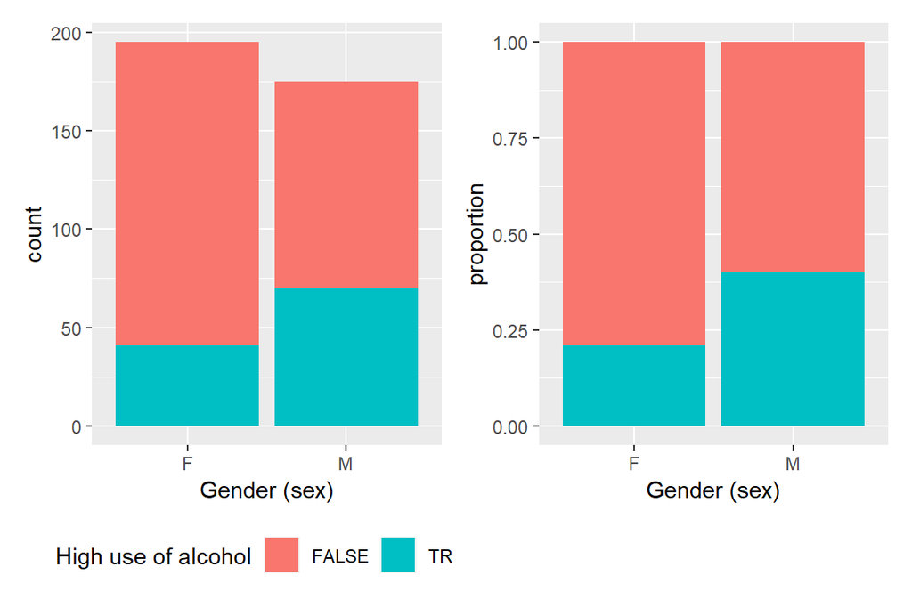

```r
#count plot
t1 <- data %>%
  ggplot(aes(x = sex, fill = high_use)) +
  geom_bar() +
  theme(legend.position = "none")+
  theme(legend.position = "bottom")+
  labs(x = "Gender (sex)")
t1 <- t1 + scale_fill_discrete(name = "High use of alcohol")

#proportion plot
t2 <- data %>%
  ggplot(aes(x = sex, fill = high_use)) +
  geom_bar(position = "fill") +
  ylab("proportion")+
  theme(legend.position = "none")+
  labs(x = "Gender (sex)")

t1+t2
```

From the bar plot above, we can see that even though we have more female students in the data, the number of male students with high alcohol consumption is higher. This is more apparent in the proportion plot, where we can see that the proportion of students with high alcohol consumption is a lot higher in male students compared to female students.

### Alcohol use and school absences

```r
data %>%
  summary_factorlist(dependent   = "high_use",
                     explanatory = "absences")
```

```
##     label    levels     FALSE      TRUE
##  absences Mean (SD) 3.7 (4.5) 6.4 (7.1)
```

Students with high alcohol consumption on average has around 6.4 absences, while students with lower alcohol consumption on average has 3.7 absences. Next, we will also compare the distribution of each groups with box plots.

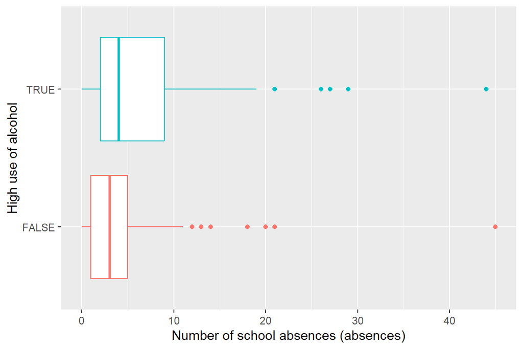

```r
data %>%
  ggplot(aes(x = absences, y = high_use)) +
  geom_boxplot(aes(colour=high_use))+
  labs(x = "Number of school absences (absences)",
       y = "High use of alcohol")+
  theme(legend.position = "none")
```

Students with high alcohol consumption have a higher school absences median compared to students with lower use of alcohol. Both groups have quite skewed data, which means that most students have very few absences but there are some students who have very high number of absences.

### Alcohol use and study time

For better presentation of the data, I will first recode the variable:

```r
data <- data %>%
  mutate(studytime2 = studytime %>% factor() %>%
           fct_recode("<2 hours" = "1", "2-5 hours" = "2",
                      "5-10 hours" = "3", ">10 hours" = "4"))
```

```r
#cross tabulation
data %>%
  summary_factorlist(dependent   = "high_use",
                     explanatory = "studytime2")
```

```
##       label     levels      FALSE      TRUE
##  studytime2   <2 hours  56 (21.6) 42 (37.8)
##              2-5 hours 128 (49.4) 57 (51.4)
##             5-10 hours  52 (20.1)   8 (7.2)
##              >10 hours   23 (8.9)   4 (3.6)
```

Among students who have high alcohol consumption, 51.4 percent spend 2-5 hours/week studying and 37.8 percent spend less than 2 hours studying. In total, 89.2 percent of students with high alcohol consumption spend 5 hours or less per week for studying, which is quite a high number. Next, we will visualize this with plots.

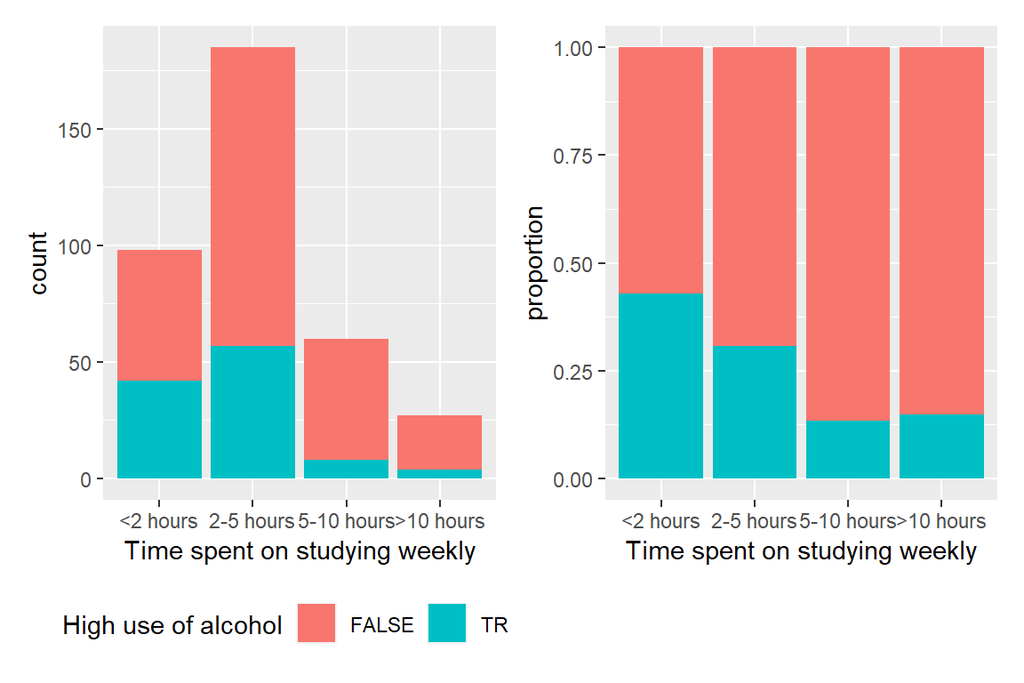

```r
#count plot
f1 <- data %>%
  ggplot(aes(x = studytime2, fill = high_use)) +
  geom_bar() +
  theme(legend.position = "none")+
  theme(legend.position = "bottom")+
  labs(x = "Time spent on studying weekly")
f1 <- f1 + scale_fill_discrete(name = "High use of alcohol")

#proportion plot
f2 <- data %>%
  ggplot(aes(x = studytime2, fill = high_use)) +
  geom_bar(position = "fill") +
  ylab("proportion")+
  theme(legend.position = "none")+
  labs(x = "Time spent on studying weekly")

f1+f2
```

Most students spent 2-5 hours weekly for studying. Students in this group also have the highest count of students with high alcohol consumption, but according to the proportion plot, students who spend lest than 2 hours for studying have the highest proportion of students with high alcohol consumption. Meanwhile, the proportion of students with high alcohol consumption is not very different between the group of students who study for 5-10 hours/week and students who spend more than 10 hours/week to study.

### Alcohol use and going out

For better presentation of the data, I will first recode the variable:

```r
data <- data %>%
  mutate(goout2 = goout %>% factor() %>%
           fct_recode("very rarely" = "1", "rarely" = "2",
                      "medium" = "3", "often" = "4", "very often" = "5"))
```

```r
#cross tabulation
data %>%
  summary_factorlist(dependent   = "high_use",
                     explanatory = "goout2")
```

```
##   label      levels     FALSE      TRUE
##  goout2 very rarely  19 (7.3)   3 (2.7)
##              rarely 82 (31.7) 15 (13.5)
##              medium 97 (37.5) 23 (20.7)
##               often 40 (15.4) 38 (34.2)
##          very often  21 (8.1) 32 (28.8)
```

Among students with high alcohol consumption, 34.2 percent go out often with their friends and 28.8 percent go out very often. From this table, we can already see that the proportion of students with high alcohol consumption is higher in groups of students who go out more often, but we will check this with plots.

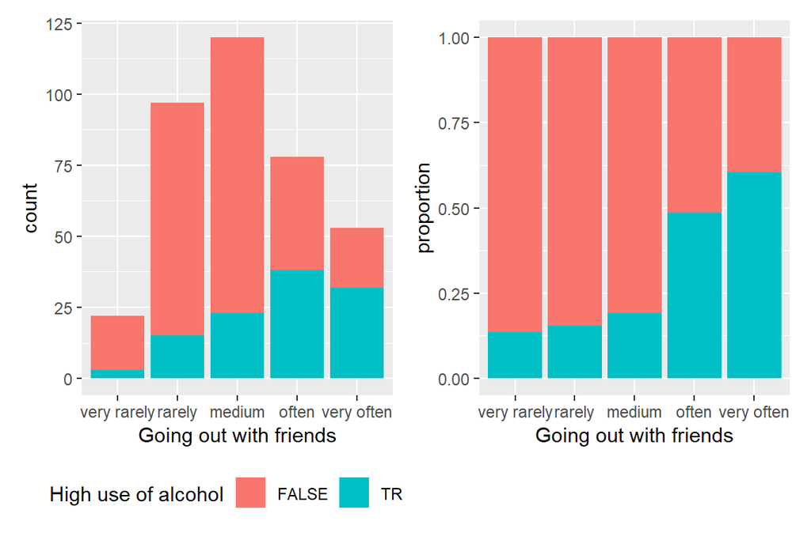

```r
#count plot
g1 <- data %>%
  ggplot(aes(x = goout2, fill = high_use)) +
  geom_bar() +
  theme(legend.position = "none")+
  theme(legend.position = "bottom")+
  labs(x = "Going out with friends")
g1 <- g1 + scale_fill_discrete(name = "High use of alcohol")

#proportion plot
g2 <- data %>%
  ggplot(aes(x = goout2, fill = high_use)) +
  geom_bar(position = "fill") +
  ylab("proportion")+
  theme(legend.position = "none")+
  labs(x = "Going out with friends")

g1+g2
```

In the proportion plot, we can see that the proportion of students with high alcohol consumption gets higher in groups of students who go out more. The difference is subtle between the groups of students who go out less often, but in groups of students who go out often or very often, the proportion is very high.

## Logistic regression

### Summary

```r
# find the model with glm()
# I will treat all explanatory variables as factors except for absences
m <- glm(high_use ~ sex + absences + studytime2 + goout2, data = data, family = "binomial")

# print out a summary of the model
summary(m)
```

```
##
## Call:
## glm(formula = high_use ~ sex + absences + studytime2 + goout2,
##     family = "binomial", data = data)
##
## Deviance Residuals:
##     Min       1Q   Median       3Q      Max
## -1.8789  -0.7759  -0.4636   0.7578   2.4917
##
## Coefficients:
##                      Estimate Std. Error z value Pr(>|z|)
## (Intercept)          -2.55088    0.72954  -3.497 0.000471 ***
## sexM                  0.89483    0.27955   3.201 0.001370 **
## absences              0.07846    0.02312   3.394 0.000688 ***
## studytime22-5 hours  -0.40001    0.30551  -1.309 0.190424
## studytime25-10 hours -0.89977    0.48249  -1.865 0.062205 .
## studytime2>10 hours  -1.17641    0.63893  -1.841 0.065591 .
## goout2rarely          0.44073    0.73079   0.603 0.546448
## goout2medium          0.69593    0.71421   0.974 0.329855
## goout2often           2.10900    0.71571   2.947 0.003212 **
## goout2very often      2.37031    0.73186   3.239 0.001200 **
## ---
## Signif. codes:  0 '***' 0.001 '**' 0.01 '*' 0.05 '.' 0.1 ' ' 1
##
## (Dispersion parameter for binomial family taken to be 1)
##
##     Null deviance: 452.04  on 369  degrees of freedom
## Residual deviance: 362.43  on 360  degrees of freedom
## AIC: 382.43
##
## Number of Fisher Scoring iterations: 4
```

According to the p-value and the positive estimate, male students significantly have higher tendency to have high alcohol consumption (p-value = 0.0014). The number of absences was also found to be a significant predictor to high alcohol consumption (p-value = 0.0007). Meanwhile, students who spend 5 hours or more for studying each week were found to be significantly less likely to have high alcohol consumption at 0.1 level compared to students who study less than 2 hours/week (p-value = 0.062 for students who study 5-10 hours/week and 0.065 for students who study more than 10 hours/week). Students who go out often or very often are significantly more likely to have high alcohol consumption compared to students who go out very rarely (p-value = 0.003 for students who go out often and 0.001 for students who go out very often).

### Odds ratio and confidence interval

```r
# compute odds ratios (OR)
OR <- coef(m) %>% exp

# compute confidence intervals (CI)
CI <- confint(m) %>% exp()
# print out the odds ratios with their confidence intervals
cbind(OR, CI)
```

```
##                               OR      2.5 %    97.5 %
## (Intercept)           0.07801306 0.01489892  0.281652
## sexM                  2.44691728 1.42235692  4.267696
## absences              1.08162325 1.03506042  1.134694
## studytime22-5 hours   0.67031109 0.36749404  1.221300
## studytime25-10 hours  0.40666321 0.15038986  1.014202
## studytime2>10 hours   0.30838487 0.07773944  0.998947
## goout2rarely          1.55384652 0.41639530  7.944878
## goout2medium          2.00557429 0.56021310 10.005175
## goout2often           8.23995705 2.30747880 41.326016
## goout2very often     10.70074528 2.88295245 54.872360
```

The table above presents the odds ratio for each variable in the model and its confidence interval.

1. Male students are 2.45 (CI = 1.42 - 4.27) times more likely to have high alcohol consumption compared to female students. This finding supports our original hypothesis.
2. For each increase in the number of school absences, the students are 1.08 (CI = 1.04 - 1.13) times more likely to have high alcohol consumption. This finding also supports our original hypothesis.
3. We found a very weak evidence of a relationship between time spent on studying and high alcohol consumption. The only group within the study time variable that has a confidence interval that do not cross 1 is the group of students who study for more than 10 hours a week. The students in this group are 3.25 (CI = 1.002 - 12.82) times less likely to have high alcohol consumption compared to students who study for less than 2 hours/week. I flipped the odds (1/x) to have a more intuitive interpretation. Meanwhile, every other groups in this variable have a confidence interval that crosses 1, which means that from this model, it is unclear if they are significantly less likely to have high alcohol consumption.
4. Compared to students who very rarely go out, students who go out often are 8.24 (CI = 2.31 - 41.33) times more likely to have higher alcohol consumption. Students who go out very often are 10.7 (CI = 2.89 - 54.87) times more likely to have higher alcohol consumption. Meanwhile, it is not apparent from the model if students who go out moderately or rarely are significantly more likely to have high alcohol consumption compared to students who very rarely go out. In general, this finding goes in line with our original hypothesis.

## Exploring the predictive power

I will use all variables since they are all significant at least at 0.1 level.

```r
# predict() the probability of high_use
probabilities <- predict(m, type = "response")

# add the predicted probabilities to data
data <- mutate(data, probability = probabilities)

# use the probabilities to make a prediction of high_use
data <- mutate(data, prediction = probabilities > 0.5)

# tabulate the target variable versus the predictions
table(high_use = data$high_use, prediction = data$prediction)
```

```
##         prediction
## high_use FALSE TRUE
##    FALSE   239   20
##    TRUE     55   56
```

Among 294 students who are predicted to not have high alcohol consumption, 239 are predicted correctly. Meanwhile, among 76 students who are predicted to have high alcohol consumption, 56 are predicted correctly. Next we will visualize this with a plot.

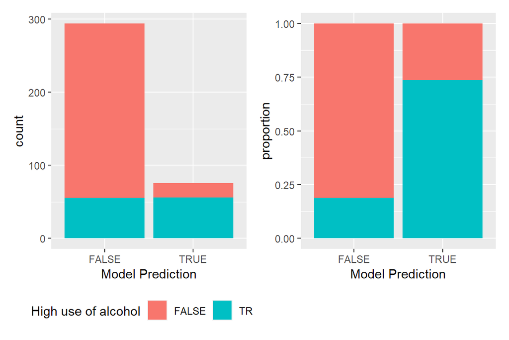

```r
#count plot
p1 <- data %>%
  ggplot(aes(x = prediction, fill = high_use)) +
  geom_bar() +
  theme(legend.position = "none")+
  theme(legend.position = "bottom")+
  labs(x = "Model Prediction")
p1 <- p1 + scale_fill_discrete(name = "High use of alcohol")

#proportion plot
p2 <- data %>%
  ggplot(aes(x = prediction, fill = high_use)) +
  geom_bar(position = "fill") +
  ylab("proportion")+
  theme(legend.position = "none")+
  labs(x = "Model Prediction")

p1+p2
```

From the proportion plot, we can see that most of the students predicted to have high alcohol consumption do have a high alcohol consumption in the data, and vice versa. Next, we will compute the total proportion of inaccurately classified individuals.

```r
# define a loss function (average prediction error)
loss_func <- function(class, prob) {
  n_wrong <- abs(class - prob) > 0.5
  mean(n_wrong)
}

# call loss_func to compute the average number of wrong predictions in the (training) data
train_er <- loss_func(class = data$high_use, prob = data$probability)
train_er
```

```
## [1] 0.2027027
```

The proportion of wrong predictions is 20.27 percent, which is a lot better than simple guessing strategy (50 percent).

## 10-fold cross validation

```r
library(boot)
```

```r
cv <- cv.glm(data = data, cost = loss_func, glmfit = m, K = 10)

# average number of wrong predictions in the cross validation
test_er <- cv$delta[1]
test_er
```

```
## [1] 0.2297297
```

## Cross validation comparison

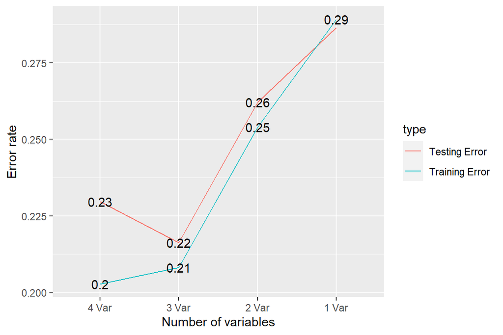

```r
# model with 3 variables
m3 <- glm(high_use ~ sex + absences + goout2, data = data, family = "binomial")
probabilities3 <- predict(m3, type = "response")
data <- mutate(data, probability3 = probabilities3)
data <- mutate(data, prediction3 = probabilities3 > 0.5)
train_er3 <- loss_func(class = data$high_use, prob = data$probability3)
cv3 <- cv.glm(data = data, cost = loss_func, glmfit = m3, K = 10)
test_er3 <- cv3$delta[1]

# model with 2 variables
m2 <- glm(high_use ~ sex + absences, data = data, family = "binomial")
probabilities2 <- predict(m2, type = "response")
data <- mutate(data, probability2 = probabilities2)
data <- mutate(data, prediction2 = probabilities2 > 0.5)
train_er2 <- loss_func(class = data$high_use, prob = data$probability2)
cv2 <- cv.glm(data = data, cost = loss_func, glmfit = m2, K = 10)
test_er2 <- cv2$delta[1]

# model with 1 variable
m1 <- glm(high_use ~ absences, data = data, family = "binomial")
probabilities1 <- predict(m1, type = "response")
data <- mutate(data, probability1 = probabilities1)
data <- mutate(data, prediction1 = probabilities1 > 0.5)
train_er1 <- loss_func(class = data$high_use, prob = data$probability1)
cv1 <- cv.glm(data = data, cost = loss_func, glmfit = m1, K = 10)
test_er1 <- cv1$delta[1]

#plotting
compare <- data.frame(model = c("4 Var", "3 Var", "2 Var", "1 Var",
                                "4 Var", "3 Var", "2 Var", "1 Var"),
                      error = c(train_er, train_er3, train_er2, train_er1,
                                test_er, test_er3, test_er2, test_er1),
                      type = c("Training Error", "Training Error",
                               "Training Error", "Training Error",
                               "Testing Error", "Testing Error",
                               "Testing Error", "Testing Error"))

compare %>%
  ggplot(aes(x = model, y = error, group = type)) +
  geom_line(aes(colour = type))+
  scale_x_discrete(limits = rev) +
  labs(x = "Number of variables",
       y = "Error rate")+
  geom_text(
    label=round(compare$error, digits=2),
    check_overlap = T)
```

Generally, both testing and training error is higher as the number of variables in the model gets lower. This is not surprising as models with higher number of (appropriate) variables would tend to have better prediction. However, we see a dip in testing error rate at three variables compared to a model with four variables. This may mean that the fourth variable we add to the model did not help better the prediction much, so it may be better to use the three variables model instead.